# **Practical Lab 3 - Vanilla CNN and Fine-Tune VGG16 - for Dogs and Cats Classification**

# 2. Fine-Tune VGG16 (pre-trained on imagenet). Make sure to use validation to test for over-fitting. Plot the appropriate graph.

```
Found 2000 images belonging to 2 classes.
Found 1000 images belonging to 2 classes.
Found 2000 images belonging to 2 classes.
63/63 ━━━━━━━━━━━━━━━━━━━━ 160s 3s/step - accuracy: 0.7193 - loss: 0.5396 - val_accuracy: 0.9310 - val_loss: 0.1586
63/63 ━━━━━━━━━━━━━━━━━━━━ 139s 2s/step - accuracy: 0.9193 - loss: 0.2152 - val_accuracy: 0.9440 - val_loss: 0.1385
63/63 ━━━━━━━━━━━━━━━━━━━━ 139s 2s/step - accuracy: 0.9253 - loss: 0.1712 - val_accuracy: 0.9250 - val_loss: 0.1784
63/63 ━━━━━━━━━━━━━━━━━━━━ 140s 2s/step - accuracy: 0.9458 - loss: 0.1374 - val_accuracy: 0.9350 - val_loss: 0.1417
63/63 ━━━━━━━━━━━━━━━━━━━━ 140s 2s/step - accuracy: 0.9505 - loss: 0.1287 - val_accuracy: 0.9470 - val_loss: 0.1215
63/63 ━━━━━━━━━━━━━━━━━━━━ 139s 2s/step - accuracy: 0.9617 - loss: 0.0973 - val_accuracy: 0.9250 - val_loss: 0.1661
63/63 ━━━━━━━━━━━━━━━━━━━━ 139s 2s/step - accuracy: 0.9628 - loss: 0.0928 - val_accuracy: 0.9330 - val_loss: 0.1568
63/63 ━━━━━━━━━━━━━━━━━━━━ 139s 2s/step - accuracy: 0.9708 - loss: 0.0807 - val_accuracy: 0.9500 - val_loss: 0.1279
63/63 ━━━━━━━━━━━━━━━━━━━━ 139s 2s/step - accuracy: 0.9689 - loss: 0.0852 - val_accuracy: 0.9550 - val_loss: 0.1174
63/63 ━━━━━━━━━━━━━━━━━━━━ 138s 2s/step - accuracy: 0.9774 - loss: 0.0540 - val_accuracy: 0.9330 - val_loss: 0.1649
63/63 ━━━━━━━━━━━━━━━━━━━━ 139s 2s/step - accuracy: 0.9625 - loss: 0.1011 - val_accuracy: 0.9520 - val_loss: 0.1615
63/63 ━━━━━━━━━━━━━━━━━━━━ 139s 2s/step - accuracy: 0.9693 - loss: 0.0713 - val_accuracy: 0.9620 - val_loss: 0.1212
63/63 ━━━━━━━━━━━━━━━━━━━━ 138s 2s/step - accuracy: 0.9819 - loss: 0.0510 - val_accuracy: 0.9470 - val_loss: 0.1369
63/63 ━━━━━━━━━━━━━━━━━━━━ 140s 2s/step - accuracy: 0.9729 - loss: 0.0653 - val_accuracy: 0.9530 - val_loss: 0.1132
63/63 ━━━━━━━━━━━━━━━━━━━━ 138s 2s/step - accuracy: 0.9702 - loss: 0.0687 - val_accuracy: 0.9540 - val_loss: 0.1191
63/63 ━━━━━━━━━━━━━━━━━━━━ 140s 2s/step - accuracy: 0.9852 - loss: 0.0358 - val_accuracy: 0.9380 - val_loss: 0.1676
63/63 ━━━━━━━━━━━━━━━━━━━━ 169s 3s/step - accuracy: 0.9845 - loss: 0.0317 - val_accuracy: 0.9580 - val_loss: 0.1803
63/63 ━━━━━━━━━━━━━━━━━━━━ 142s 2s/step - accuracy: 0.9841 - loss: 0.0354 - val_accuracy: 0.9550 - val_loss: 0.1531
63/63 ━━━━━━━━━━━━━━━━━━━━ 143s 2s/step - accuracy: 0.9886 - loss: 0.0370 - val_accuracy: 0.9360 - val_loss: 0.1992
```

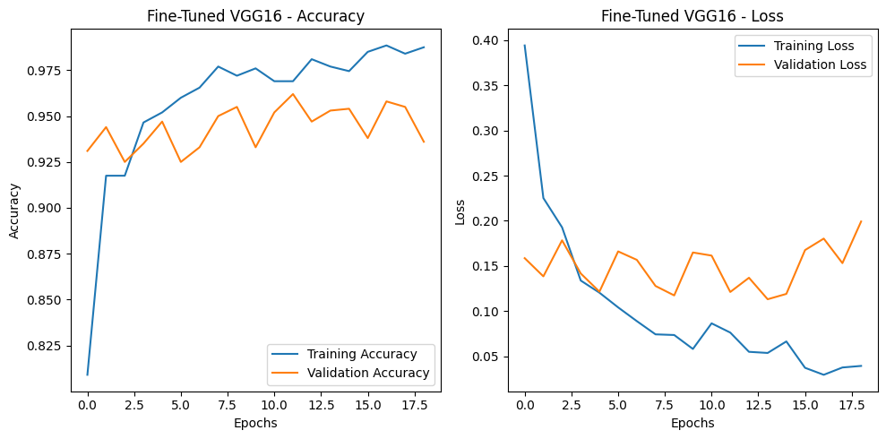

```
Evaluating Fine-Tuned Model on Test Data
63/63 ━━━━━━━━━━━━━━━━━━━━ 84s 1s/step - accuracy: 0.9801 - loss: 0.0668
Test Loss: 0.08077238500118256, Test Accuracy: 0.9725000262260437
```

```python
from tensorflow.keras.applications import VGG16
from tensorflow.keras import layers, models, optimizers
from tensorflow.keras.callbacks import ModelCheckpoint, EarlyStopping
from tensorflow.keras.preprocessing.image import ImageDataGenerator
import matplotlib.pyplot as plt

# Paths
train_dir = '../data/kaggle_dogs_vs_cats_small/train'
validation_dir = '../data/kaggle_dogs_vs_cats_small/validation'
test_dir = '../data/kaggle_dogs_vs_cats_small/test'

# Image dimensions and batch size
IMG_HEIGHT, IMG_WIDTH = 224, 224
BATCH_SIZE = 32

# Data augmentation and normalization
train_datagen = ImageDataGenerator(
    rescale=1.0/255,
    rotation_range=20,
    width_shift_range=0.2,
    height_shift_range=0.2,
    shear_range=0.2,
    zoom_range=0.2,
    horizontal_flip=True,
    fill_mode='nearest'
)
validation_datagen = ImageDataGenerator(rescale=1.0/255)
test_datagen = ImageDataGenerator(rescale=1.0/255)

# Data generators
train_generator = train_datagen.flow_from_directory(
    train_dir,
    target_size=(IMG_HEIGHT, IMG_WIDTH),
    batch_size=BATCH_SIZE,
    class_mode='binary'
)
validation_generator = validation_datagen.flow_from_directory(
    validation_dir,
    target_size=(IMG_HEIGHT, IMG_WIDTH),
    batch_size=BATCH_SIZE,
    class_mode='binary'
)
test_generator = test_datagen.flow_from_directory(
    test_dir,
    target_size=(IMG_HEIGHT, IMG_WIDTH),
    batch_size=BATCH_SIZE,
    class_mode='binary'
)

# Fine-Tune VGG16 Model
base_model = VGG16(weights='imagenet', include_top=False, input_shape=(IMG_HEIGHT, IMG_WIDTH, 3))
base_model.trainable = True

# Fine-tune the last few layers
for layer in base_model.layers[:-4]:
    layer.trainable = False

model = models.Sequential([
    base_model,
    layers.Flatten(),
    layers.Dense(512, activation='relu'),
    layers.Dropout(0.5),
    layers.Dense(1, activation='sigmoid')
])

# Compile the model
model.compile(optimizer=optimizers.Adam(learning_rate=1e-4),
              loss='binary_crossentropy',
              metrics=['accuracy'])

# Callbacks
checkpoint = ModelCheckpoint('best_vgg16_finetuned_model.keras', save_best_only=True, monitor='val_loss', mode='min')
early_stopping = EarlyStopping(monitor='val_loss', patience=5, restore_best_weights=True)

# Train the model
history = model.fit(
    train_generator,
    epochs=20,
    validation_data=validation_generator,
    callbacks=[checkpoint, early_stopping]
)

# Plot Training and Validation Metrics
def plot_training_history(history, model_name="Fine-Tuned VGG16"):
    acc = history.history['accuracy']
    val_acc = history.history['val_accuracy']
    loss = history.history['loss']
    val_loss = history.history['val_loss']
    epochs_range = range(len(acc))

    # Plot Accuracy
    plt.figure(figsize=(10, 5))
    plt.subplot(1, 2, 1)
    plt.plot(epochs_range, acc, label='Training Accuracy')
    plt.plot(epochs_range, val_acc, label='Validation Accuracy')
    plt.title(f'{model_name} - Accuracy')
    plt.xlabel('Epochs')
    plt.ylabel('Accuracy')
    plt.legend(loc='lower right')

    # Plot Loss
    plt.subplot(1, 2, 2)
    plt.plot(epochs_range, loss, label='Training Loss')
    plt.plot(epochs_range, val_loss, label='Validation Loss')
    plt.title(f'{model_name} - Loss')
    plt.xlabel('Epochs')
    plt.ylabel('Loss')
    plt.legend(loc='upper right')

    plt.tight_layout()
    plt.show()

plot_training_history(history, model_name="Fine-Tuned VGG16")

# Evaluate the best model on the test data
print("Evaluating Fine-Tuned Model on Test Data")
test_loss, test_accuracy = model.evaluate(test_generator)
print(f"Test Loss: {test_loss}, Test Accuracy: {test_accuracy}")
```

# 4.Explore the relative performance of the models (make sure to load the best version of each model)

- accuracy
- confusion metric
- precision, recall, F1-score,
- precision-recall curve.
- Explore specific examples in which the model failed to predict correctly.

```
Found 2000 images belonging to 2 classes.
Evaluating Model 1
Model 1 Test Accuracy: 0.9265000224113464
Evaluating Model 2 (Fine-Tuned VGG16)
Model 2 Test Accuracy: 0.9725000262260437
2000/2000 ━━━━━━━━━━━━━━━━━━━━ 150s 75ms/step
2000/2000 ━━━━━━━━━━━━━━━━━━━━ 153s 76ms/step
Confusion Matrix - Model 1:
[[925  75]
 [ 72 928]]

Confusion Matrix - Model 2:
[[981  19]
 [ 36 964]]

Classification Report - Model 1:
              precision    recall  f1-score   support

         cat       0.93      0.93      0.93      1000
         dog       0.93      0.93      0.93      1000

    accuracy                           0.93      2000
   macro avg       0.93      0.93      0.93      2000
weighted avg       0.93      0.93      0.93      2000


Classification Report - Model 2:
              precision    recall  f1-score   support

         cat       0.96      0.98      0.97      1000
         dog       0.98      0.96      0.97      1000

    accuracy                           0.97      2000
   macro avg       0.97      0.97      0.97      2000
weighted avg       0.97      0.97      0.97      2000

2000/2000 ━━━━━━━━━━━━━━━━━━━━ 150s 75ms/step
2000/2000 ━━━━━━━━━━━━━━━━━━━━ 146s 73ms/step
```

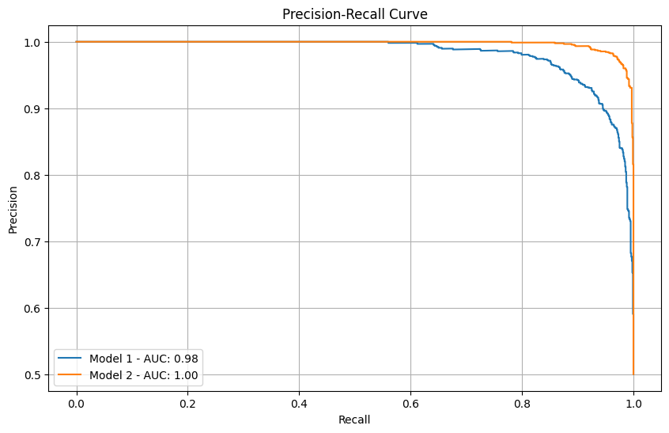

```
Examples of Misclassifications - Model 1: [ 6  7  9 24 63]
Examples of Misclassifications - Model 2: [  7  75 119 145 299]
```

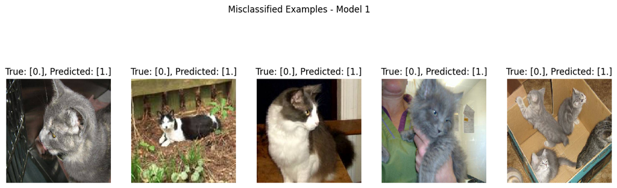

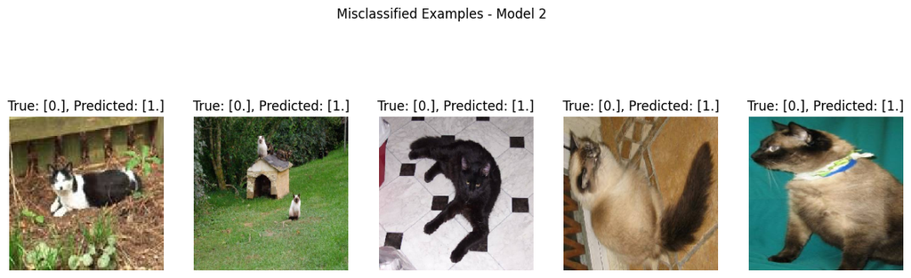

```python
import numpy as np
import matplotlib.pyplot as plt
from sklearn.metrics import confusion_matrix, classification_report, precision_recall_curve, auc
from tensorflow.keras.models import load_model

# Paths
test_dir = '../data/kaggle_dogs_vs_cats_small/test'

# Reload test data generator
test_datagen = ImageDataGenerator(rescale=1.0/255)
test_generator = test_datagen.flow_from_directory(
    test_dir,
    target_size=(IMG_HEIGHT, IMG_WIDTH),
    batch_size=1,
    class_mode='binary',
    shuffle=False
)

# Load the best saved models
best_model_path_1 = 'best_model_1.keras'
best_model_path_2 = 'best_vgg16_finetuned_model.keras'

model_1 = load_model(best_model_path_1)
model_2 = load_model(best_model_path_2)

# Evaluate the models
print("Evaluating Model 1 ")
test_loss_1, test_acc_1 = model_1.evaluate(test_generator, verbose=0)
print(f"Model 1 Test Accuracy: {test_acc_1}")

print("Evaluating Model 2 (Fine-Tuned VGG16)")
test_loss_2, test_acc_2 = model_2.evaluate(test_generator, verbose=0)
print(f"Model 2 Test Accuracy: {test_acc_2}")

# Predictions
test_steps = len(test_generator)
y_true = test_generator.classes
y_pred_1 = (model_1.predict(test_generator, steps=test_steps) > 0.5).astype("int32").flatten()
y_pred_2 = (model_2.predict(test_generator, steps=test_steps) > 0.5).astype("int32").flatten()

# Confusion Matrices
conf_matrix_1 = confusion_matrix(y_true, y_pred_1)
conf_matrix_2 = confusion_matrix(y_true, y_pred_2)
print("Confusion Matrix - Model 1:")
print(conf_matrix_1)
print("\nConfusion Matrix - Model 2:")
print(conf_matrix_2)

# Classification Reports
print("\nClassification Report - Model 1:")
print(classification_report(y_true, y_pred_1, target_names=test_generator.class_indices.keys()))

print("\nClassification Report - Model 2:")
print(classification_report(y_true, y_pred_2, target_names=test_generator.class_indices.keys()))

# Precision-Recall Curves
y_scores_1 = model_1.predict(test_generator, steps=test_steps).flatten()
y_scores_2 = model_2.predict(test_generator, steps=test_steps).flatten()
precision_1, recall_1, _ = precision_recall_curve(y_true, y_scores_1)
precision_2, recall_2, _ = precision_recall_curve(y_true, y_scores_2)

auc_1 = auc(recall_1, precision_1)
auc_2 = auc(recall_2, precision_2)

plt.figure(figsize=(10, 6))
plt.plot(recall_1, precision_1, label=f'Model 1 - AUC: {auc_1:.2f}')
plt.plot(recall_2, precision_2, label=f'Model 2 - AUC: {auc_2:.2f}')
plt.title('Precision-Recall Curve')
plt.xlabel('Recall')
plt.ylabel('Precision')
plt.legend()
plt.grid()
plt.show()

# Analyze Examples of Misclassifications
misclassified_indices_1 = np.where(y_true != y_pred_1)[0]
misclassified_indices_2 = np.where(y_true != y_pred_2)[0]

print(f"Examples of Misclassifications - Model 1: {misclassified_indices_1[:5]}")
print(f"Examples of Misclassifications - Model 2: {misclassified_indices_2[:5]}")

# Visualize Misclassified Examples
def plot_misclassified_examples(generator, indices, model_name):
    plt.figure(figsize=(15, 5))
    for i, idx in enumerate(indices[:5]):
        img, label = generator[idx]
        plt.subplot(1, 5, i + 1)
        plt.imshow(img[0])
        plt.title(f"True: {label}, Predicted: {1-label}")
        plt.axis('off')
    plt.suptitle(f'Misclassified Examples - {model_name}')
    plt.show()

plot_misclassified_examples(test_generator, misclassified_indices_1, "Model 1")
plot_misclassified_examples(test_generator, misclassified_indices_2, "Model 2")
```

# **CONCLUSION**

The output provides a detailed comparison between two models for binary classification of images (cats vs. dogs):

#### **2. Why Fine-Tuning Works**

- **Model 1**:
  - Uses the pre-trained VGG16 base model with frozen layers, which retains general-purpose features learned from ImageNet.
  - Limitation: Since the base model isn't retrained, it doesn't adapt fully to task-specific features (cats vs. dogs).
- **Model 2**:
  - Fine-tunes the VGG16 base by unfreezing the last few layers, allowing the model to adapt to the specific dataset.
  - This enables the model to learn task-specific features (e.g., subtle differences in texture, shape, or fur patterns), improving both precision and recall.

#### **3. Evaluation Metrics**

- **Accuracy**: Measures the overall percentage of correct predictions. Model 2's higher accuracy (**97.25%**) shows its superior performance over Model 1 (**92.65%**).
- **Precision**: Evaluates how many of the predicted positives are actually correct. Model 2 achieves better precision, meaning fewer false alarms (false positives).
- **Recall**: Evaluates how many of the actual positives are correctly identified. Model 2's higher recall shows it missed fewer true cases (false negatives).
- **F1-Score**: A balance between precision and recall. Model 2's F1-score reflects its ability to maintain both high precision and high recall.

#### **4. Confusion Matrix Analysis**

- Model 1:
  - Higher false positives (75) and false negatives (72) indicate limited ability to differentiate between classes.
- Model 2:
  - Drastically reduced errors with only 19 false positives and 36 false negatives, showing improved generalization.

#### **5. Practical Implications**

- **Precision-Recall Trade-Off**:
  - Higher precision (Model 2) reduces the risk of false positives, making it more reliable in real-world scenarios.
  - Higher recall (Model 2) ensures fewer actual cases are missed, which is critical for tasks requiring high sensitivity.
- **Error Reduction**:
  - Model 2's reduced misclassifications make it a better choice for applications requiring high accuracy and reliability.

#### **6. Key Takeaways**

1. **Fine-Tuning Matters**: Adapting pre-trained models to specific tasks by fine-tuning significantly enhances their performance.
2. **Error Reduction**: Fine-tuned models can reduce both false positives and false negatives, leading to better generalization.
3. **Balanced Metrics**: Model 2 achieves a better balance between precision, recall, and F1-score, demonstrating its robustness.
4. **Application Insight**: Model 2 is more suitable for deployment in real-world scenarios due to its higher accuracy and lower misclassification rates.